# NBASalary

Daniel Corral Ruiz

Miercoles, 28 Octubre, 2020

La finalidad de este estudio se basa en crear el mejor modelo de regresión lineal con la finalidad de predecir salarios de jugadores de la NBA.

# Carga de librerías

Las librerías necesarias para comenzar con el estudio son “dplyr”, “tidyverse” y “ggplot2”.

# Carga y limpieza de datos

El dataset escogido para la predicción muestra datos sobre jugadores de baloncesto de la NBA. El objetivo es determinar el mejor modelo para predecir el salario de los jugadores de la NBA.

### Limpieza de valores nulos

En el dataset principal se encuentran 2 valores nulos. Por lo tanto se ha creado un nuevo dataset sin nungún valor na.

### Datos duplicados

Comprobación de valores duplicados en la variable “Player”, ya que complicará el estudio y por lo tanto la predicción.

# Creación de modelos

Se ha seleccionado a priori una serie de modelos con el fin de compararlos. Estos modelos presentan como variable dependiente “Salary”. Estudio de los diferentes modelos:

```
##
## Call:
## lm(formula = Salary ~ +Age + PER + TS. + TRB. + OWS + DWS + WS,
##     data = dataNBAclean)
##
## Residuals:
##       Min        1Q    Median        3Q       Max
## -14403334  -3638068   -814192   2725912  27023139
##
## Coefficients:
##             Estimate Std. Error t value Pr(>|t|)
## (Intercept) -6697576    2211383  -3.029  0.00259 **
## Age           496616      60942   8.149 3.28e-15 ***
## PER           118352      49187   2.406  0.01650 *
## TS.         -9379508    3655526  -2.566  0.01060 *
## TRB.          -17487      54976  -0.318  0.75057
## OWS         -2461972    4840697  -0.509  0.61127
## DWS         -2007231    4834502  -0.415  0.67819
## WS           3834875    4830207   0.794  0.42763
## ---
## Signif. codes:  0 '***' 0.001 '**' 0.01 '*' 0.05 '.' 0.1 ' ' 1
##
## Residual standard error: 5610000 on 475 degrees of freedom
## Multiple R-squared:  0.4334, Adjusted R-squared:  0.425
## F-statistic:  51.9 on 7 and 475 DF,  p-value: < 2.2e-16
```

```
##
## Call:
## lm(formula = Salary ~ . - Player, data = dataNBAclean)
##
## Residuals:
##       Min        1Q    Median        3Q       Max
## -13909641  -2688087    -76028   2249552  20932066
##
## Coefficients:
##                              Estimate Std. Error t value Pr(>|t|)
## (Intercept)                 -12062057    7375756  -1.635 0.102790
## NBA_CountryAustralia          5473037    4453851   1.229 0.219885
## NBA_CountryAustria            1798244    6896545   0.261 0.794428
## NBA_CountryBahamas            1949514    6791044   0.287 0.774212
## NBA_CountryBosnia             8972886    6750363   1.329 0.184554
## NBA_CountryBosnia & Herz...  -4161409    6797175  -0.612 0.540750
## NBA_CountryBrazil             5294275    4721722   1.121 0.262876
## NBA_CountryCameroon          -1951149    5105640  -0.382 0.702557
## NBA_CountryCanada             4707704    4358066   1.080 0.280717
## NBA_CountryChina              5769941    6896026   0.837 0.403277
## NBA_CountryCroatia            4205678    4611771   0.912 0.362369
## NBA_CountryCzech Republic      445856    6754827   0.066 0.947408
## NBA_CountryDemocratic Re...  12761147    5517459   2.313 0.021256 *
## NBA_CountryDemocratic Re_    11261425    6769380   1.664 0.097010 .
## NBA_CountryDominican Rep...  10277768    5726386   1.795 0.073468 .
## NBA_CountryEgypt              8363757    6719515   1.245 0.214000
## NBA_CountryFinland            2780800    6777723   0.410 0.681825
## NBA_CountryFrance            10697261    4356134   2.456 0.014503 *
## NBA_CountryGeorgia            -768248    6711180  -0.114 0.908923
## NBA_CountryGermany            4441648    4680150   0.949 0.343196
## NBA_CountryGreece             4945478    5692836   0.869 0.385542
## NBA_CountryHaiti              4159615    6783209   0.613 0.540091
## NBA_CountryIsrael            -3246383    6763330  -0.480 0.631502
## NBA_CountryItaly              7904807    5491605   1.439 0.150840
## NBA_CountryLatvia             2287551    5469548   0.418 0.676009
## NBA_CountryLithuania          2566471    5259451   0.488 0.625847
## NBA_CountryMali               5169384    6767755   0.764 0.445439
## NBA_CountryMontenegro         5787771    5475448   1.057 0.291156
## NBA_CountryNew Zealand       10536076    6888758   1.529 0.126972
## NBA_CountryPoland             4288081    6701054   0.640 0.522611
```

[output cut: 59 more lines]

```
## USG.                           254705     137293   1.855 0.064333 .
## OWS                            541102    4958320   0.109 0.913156
## DWS                            366658    4966003   0.074 0.941181
## WS                              74783    4974774   0.015 0.988014
## WS.48                        16202283   16145105   1.004 0.316230
## OBPM                          5008462    5132167   0.976 0.329729
## DBPM                          5331464    5030176   1.060 0.289856
## BPM                          -4973292    5039445  -0.987 0.324325
## VORP                           388696     673130   0.577 0.563976
## ---
## Signif. codes:  0 '***' 0.001 '**' 0.01 '*' 0.05 '.' 0.1 ' ' 1
##
## Residual standard error: 5113000 on 385 degrees of freedom
## Multiple R-squared:  0.6184, Adjusted R-squared:  0.5223
## F-statistic: 6.433 on 97 and 385 DF,  p-value: < 2.2e-16
```

```
##
## Call:
## lm(formula = Salary ~ . - Player - NBA_Country - Tm, data = dataNBAclean)
##
## Residuals:
##       Min        1Q    Median        3Q       Max
## -15344434  -2975002   -390994   2102049  21682686
##
## Coefficients:
##                 Estimate Std. Error t value Pr(>|t|)
## (Intercept)     -2250339    4899140  -0.459    0.646
## NBA_DraftNumber   -60481      12755  -4.742 2.83e-06 ***
## Age               516821      56511   9.146  < 2e-16 ***
## G                -154411      24983  -6.181 1.41e-09 ***
## MP                  5657       1083   5.224 2.67e-07 ***
## PER              -355059     280566  -1.266    0.206
## TS.             -2162767    5149052  -0.420    0.675
## X3PAr           -3458209    2357905  -1.467    0.143
## FTr              -158470     886960  -0.179    0.858
## ORB.            -1055234     902929  -1.169    0.243
## DRB.             -855005     893502  -0.957    0.339
## TRB.             2006676    1788697   1.122    0.263
## AST.              -19606      47542  -0.412    0.680
## STL.             -196551     421995  -0.466    0.642
## BLK.              110238     318223   0.346    0.729
## TOV.                4208      52692   0.080    0.936
## USG.              169431     104692   1.618    0.106
## OWS             -1271685    4493110  -0.283    0.777
## DWS             -1735775    4518854  -0.384    0.701
## WS               1827796    4498896   0.406    0.685
## WS.48            1914677   11797052   0.162    0.871
## OBPM             1878971    4744860   0.396    0.692
## DBPM             1438902    4660878   0.309    0.758
## BPM             -1295954    4678340  -0.277    0.782
## VORP              629465     633799   0.993    0.321
## ---
## Signif. codes:  0 '***' 0.001 '**' 0.01 '*' 0.05 '.' 0.1 ' ' 1
##
## Residual standard error: 5103000 on 458 degrees of freedom
## Multiple R-squared:  0.5479, Adjusted R-squared:  0.5242
## F-statistic: 23.13 on 24 and 458 DF,  p-value: < 2.2e-16
```

Se observan los estadísticos de los tres modelos, teniendo importancia el valor “Adjusted R-Squared”. A priori, el mejor modelo seleccionado según el “R Cuadrado Ajustado” es el model2, ya que muestra un valor superior a los modelos anteriores.

# QQPLot

Un QQ-Plot es una representación gráfica, que sirve para comparar dos distribuciones para ver si coinciden. Es un gráfico de puntos que muestra los cuantiles. Si ambos cuantiles viene de la misma distribución, veremos que los puntos forman una linea recta, si esto no ocurre entenderemos que los datos muestrales no han sido generados por la distribución teórica. Para la representación tenemos que cargar librerias.

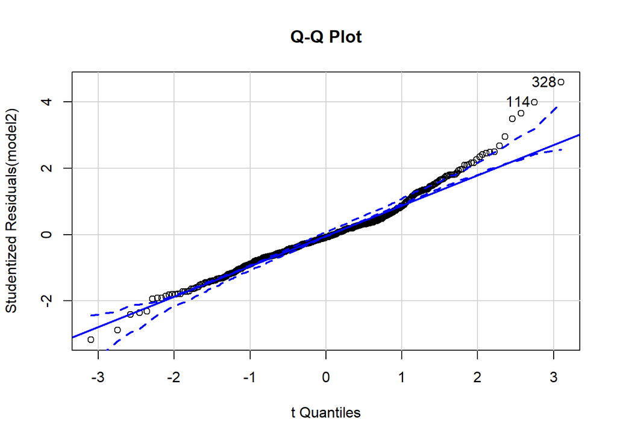

```
## 114 328
## 112 326
```

# Histograma + densidad + normal + rug

Representación curva densidad Kernel con el fin de observar normalidad.

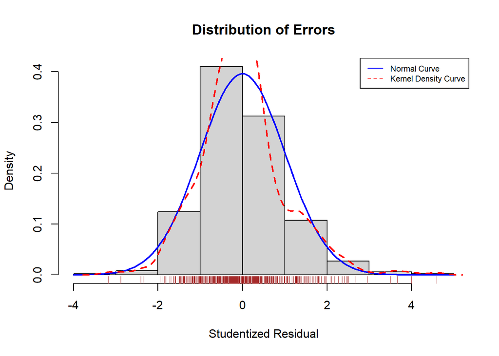

# Jarque Bera

En estadística, la prueba de Jarque-bera es una prueba de bondad de ajuste para comprobar si una muestra de datos tiene la asimetría y la curtosis de una distribución normal.

```
##
## Title:
##  Jarque - Bera Normality Test
##
## Test Results:
##   PARAMETER:
##     Sample Size: 483
##   STATISTIC:
##     LM: 84.529
##     ALM: 87.406
##   P VALUE:
##     Asymptotic: < 2.2e-16
##
## Description:
##  Wed Oct 28 19:50:25 2020 by user: danicorral
```

El p-valor del estadístico es aproximadamente 0 . Rechazamos ho, los datos no tienen asimetria y curtosis de distribución normal.

# Shapiro-Wilk

El test de Shapiro-Wilk permite comprobar si una muestra ha sido generada por una distribución normal.

```
##
##  Shapiro-Wilk normality test
##
## data:  vResid
## W = 0.97066, p-value = 2.981e-08
```

El p-valor del estadístico es aproximadamente 0 . Rechazamos ho, los datos no provienen de una distribución normal.

# Linealidad

## Componentes o gráficos de residuos parciales

Se grafican los valores ajustados con respecto a los predictores, si no hay problemas de linealidad se obtiene una recta sobre las que se representan los puntos.

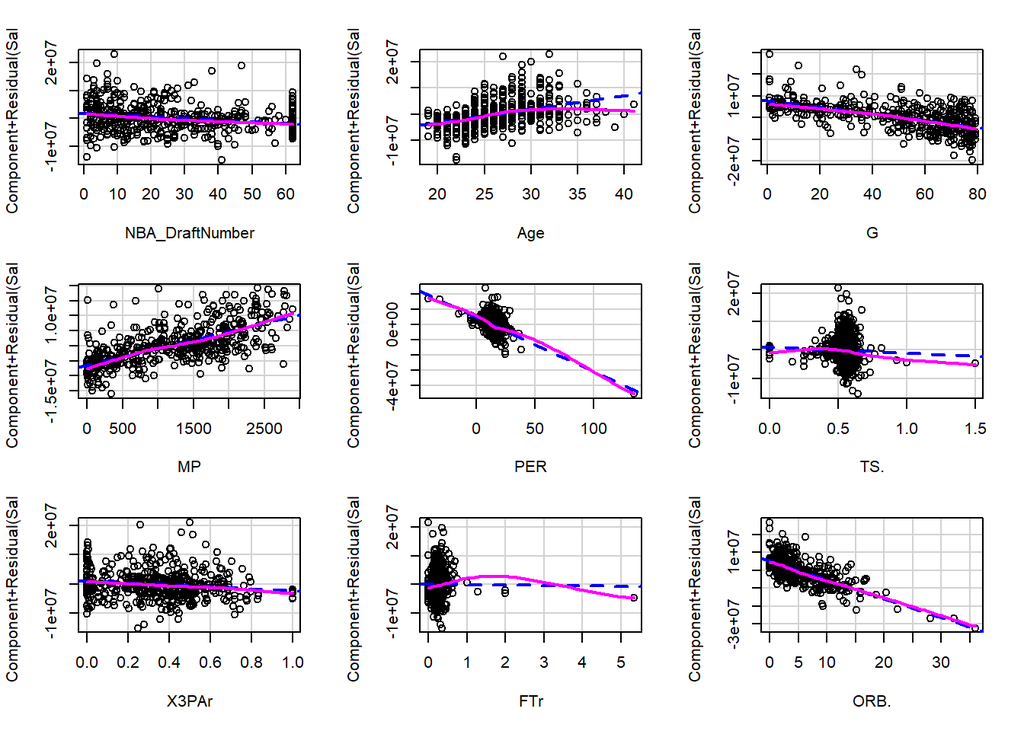

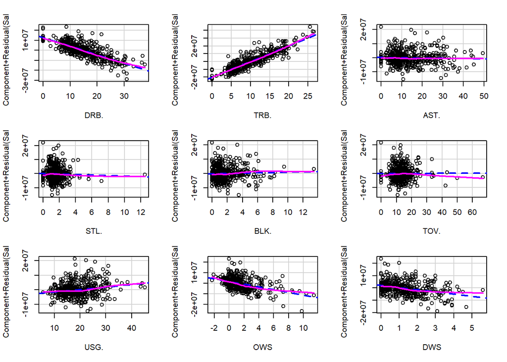

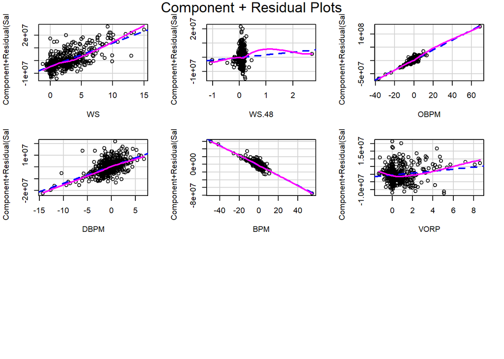

# Varianza constante. Homocedasticidad

## Varianza no constante. Breusch-Pagan

El test Breusch-Pagan se basa en las varianzas de las observaciones, donde explican la variabilidad de la varianza (varianza no constante)

```
## Non-constant Variance Score Test
## Variance formula: ~ fitted.values
## Chisquare = 91.60609, Df = 1, p = < 2.22e-16
```

Rechazamos hipótesis nula, la varianza no es constante.

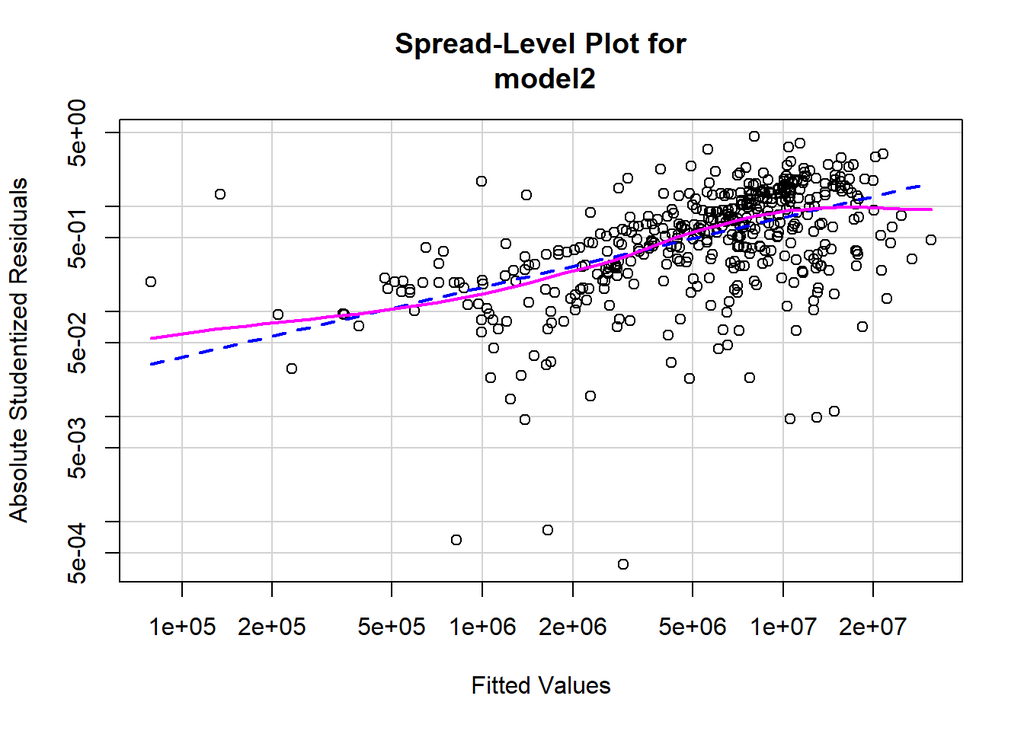

```
##
## Suggested power transformation:  0.3340916
```

# Validación global

Podemos contrastar todas las hipótesis del modelo mediante el test de Peña, EA and Slate, EH.

```
##
## Call:
## lm(formula = Salary ~ . - Player - NBA_Country - Tm, data = dataNBAclean)
##
## Residuals:
##       Min        1Q    Median        3Q       Max
## -15344434  -2975002   -390994   2102049  21682686
##
## Coefficients:
##                 Estimate Std. Error t value Pr(>|t|)
## (Intercept)     -2250339    4899140  -0.459    0.646
## NBA_DraftNumber   -60481      12755  -4.742 2.83e-06 ***
## Age               516821      56511   9.146  < 2e-16 ***
## G                -154411      24983  -6.181 1.41e-09 ***
## MP                  5657       1083   5.224 2.67e-07 ***
## PER              -355059     280566  -1.266    0.206
## TS.             -2162767    5149052  -0.420    0.675
## X3PAr           -3458209    2357905  -1.467    0.143
## FTr              -158470     886960  -0.179    0.858
## ORB.            -1055234     902929  -1.169    0.243
## DRB.             -855005     893502  -0.957    0.339
## TRB.             2006676    1788697   1.122    0.263
## AST.              -19606      47542  -0.412    0.680
## STL.             -196551     421995  -0.466    0.642
## BLK.              110238     318223   0.346    0.729
## TOV.                4208      52692   0.080    0.936
## USG.              169431     104692   1.618    0.106
## OWS             -1271685    4493110  -0.283    0.777
## DWS             -1735775    4518854  -0.384    0.701
## WS               1827796    4498896   0.406    0.685
## WS.48            1914677   11797052   0.162    0.871
## OBPM             1878971    4744860   0.396    0.692
## DBPM             1438902    4660878   0.309    0.758
## BPM             -1295954    4678340  -0.277    0.782
## VORP              629465     633799   0.993    0.321
## ---
## Signif. codes:  0 '***' 0.001 '**' 0.01 '*' 0.05 '.' 0.1 ' ' 1
##
## Residual standard error: 5103000 on 458 degrees of freedom
## Multiple R-squared:  0.5479, Adjusted R-squared:  0.5242
## F-statistic: 23.13 on 24 and 458 DF,  p-value: < 2.2e-16
##
##
## ASSESSMENT OF THE LINEAR MODEL ASSUMPTIONS
## USING THE GLOBAL TEST ON 4 DEGREES-OF-FREEDOM:
## Level of Significance =  0.05
##
## Call:
##  gvlma(x = model2)
##
##                       Value   p-value                   Decision
## Global Stat        117.1719 0.000e+00 Assumptions NOT satisfied!
## Skewness            32.4118 1.247e-08 Assumptions NOT satisfied!
## Kurtosis            52.1172 5.228e-13 Assumptions NOT satisfied!
## Link Function       32.1027 1.462e-08 Assumptions NOT satisfied!
## Heteroscedasticity   0.5402 4.623e-01    Assumptions acceptable.
```

Al modo de solo aceptar la heterocedasticidad y rechazar el resto, es indicatativo de que no existe linealidad en el modelo.

# Multicolinealidad

Es la existencia de alta correlación entre los predictores, esto puede producir problemas de imprecisión de los estimadores. Así, los intervalos de confianza son muy anchos, hay dificultad para interpretar los coeficientes y se tiende a no rechazar las hipótesis nula de significación.

## Detección de la Multicolinealidad

Para cualquier regresor la raíz del VIF indica cuantas veces es la varianza del estimador es mayor que la que se obtendría si no hubiera correlación entre los regresores. Cuando la raiz cuadrada de VIF > 2 se considera que hay problemas de multicolinealidad.

```
## NBA_DraftNumber             Age               G              MP             PER
##        1.342520        1.079819        7.060934       14.225204      111.433074
##             TS.           X3PAr             FTr            ORB.            DRB.
##        6.194013        5.297330        1.263474      316.727002      681.928718
##            TRB.            AST.            STL.            BLK.            TOV.
##     1436.507667        3.458745        3.208711        5.312844        1.921716
##            USG.             OWS             DWS              WS           WS.48
##        6.886673     1325.576479      404.022191     2679.552208       68.627896
##            OBPM            DBPM             BPM            VORP
##    10537.222382     2304.619311    13004.117445       11.572767
```

```
## NBA_DraftNumber             Age               G              MP             PER
##           FALSE           FALSE            TRUE            TRUE            TRUE
##             TS.           X3PAr             FTr            ORB.            DRB.
##            TRUE            TRUE           FALSE            TRUE            TRUE
##            TRB.            AST.            STL.            BLK.            TOV.
##            TRUE           FALSE           FALSE            TRUE           FALSE
##            USG.             OWS             DWS              WS           WS.48
##            TRUE            TRUE            TRUE            TRUE            TRUE
##            OBPM            DBPM             BPM            VORP
##            TRUE            TRUE            TRUE            TRUE
```

# Outliers

## Valores atípicos

Observaciones cuyo residuo asociado es grande. Identificamos los valores atípicos mediante un Bonferroni p-values.

```
##     rstudent unadjusted p-value Bonferroni p
## 328 4.595907         5.5825e-06    0.0026963
## 114 3.999924         7.3889e-05    0.0356890
```

## Valores extremos

Una observación es extrema si se encuentra apreciablemente alejada del resto de observaciones de la muestra.

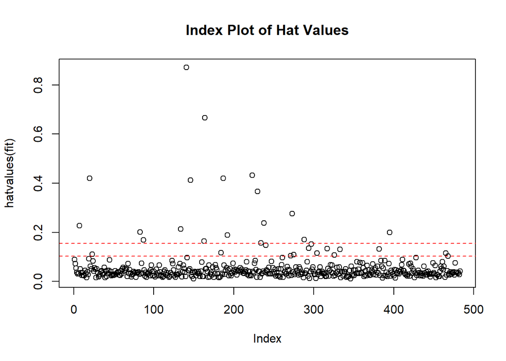

```
## integer(0)
```

## Valores influyentes

Identificamos valores influyentes

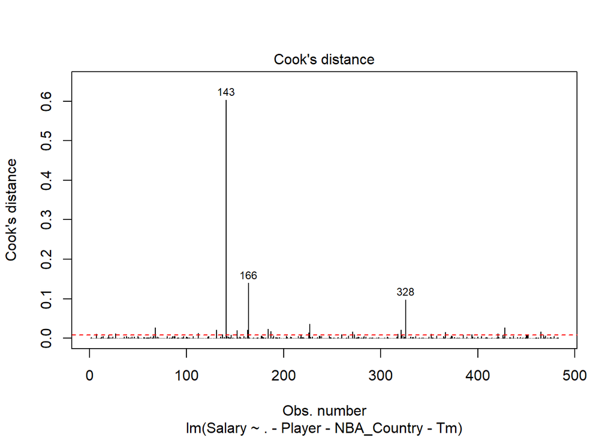

Añadimos gráficos de variables

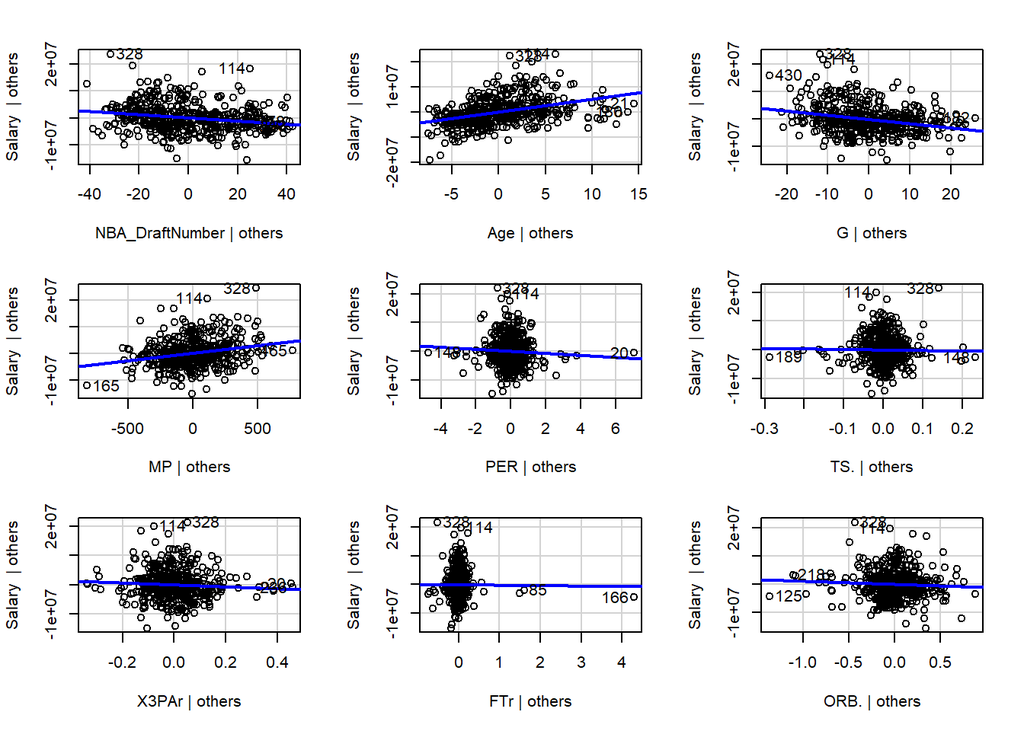

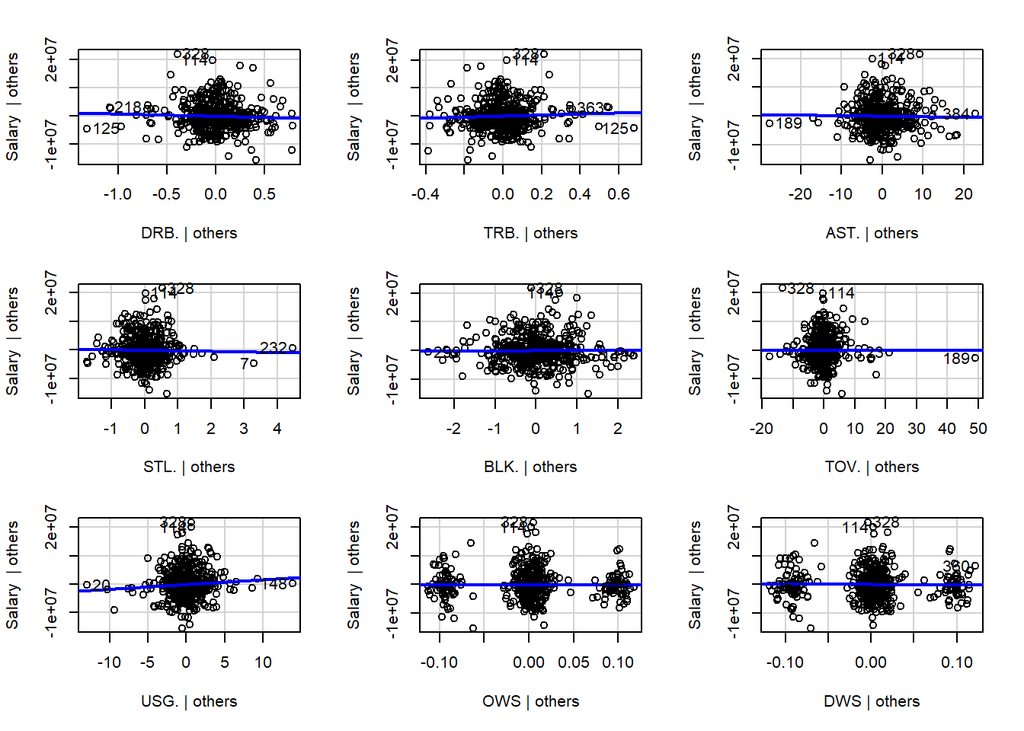

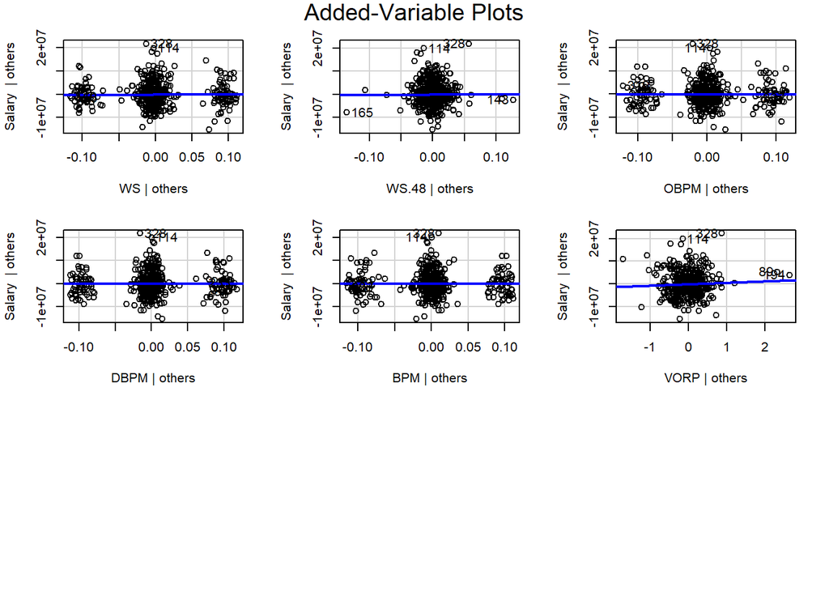

Puntos de influencia

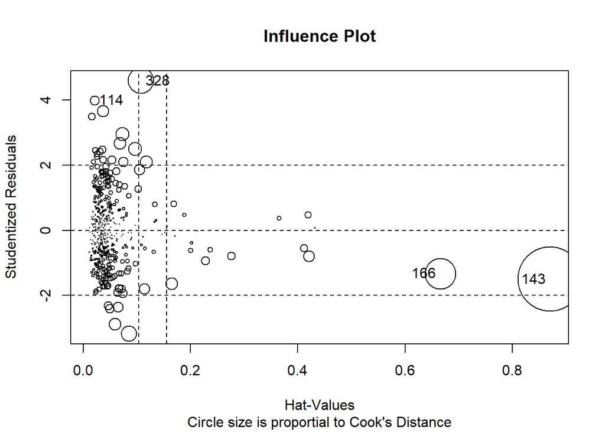

|  | StudRes | Hat | CookD |
| --- | --- | --- | --- |
| 114 | 3.999924 | 0.02088586 | 0.01321866 |
| 143 | -1.499158 | 0.87069022 | 0.60367897 |
| 166 | -1.326126 | 0.66551439 | 0.13973034 |
| 328 | 4.595907 | 0.10778593 | 0.09777366 |

# Interacción

Comprobación interacción entre variables

```
##
## Call:
## lm(formula = Salary ~ Age * PER * TS. * TRB. * OWS * DWS * WS,
##     data = dataNBAclean)
##
## Residuals:
##       Min        1Q    Median        3Q       Max
## -12088902  -2467546   -694388   1626254  25637953
##
## Coefficients:
##                               Estimate Std. Error t value Pr(>|t|)
## (Intercept)                  8.687e+06  3.567e+07   0.244   0.8078
## Age                         -1.931e+05  1.335e+06  -0.145   0.8850
## PER                          3.067e+06  2.468e+06   1.243   0.2149
## TS.                         -6.516e+07  9.047e+07  -0.720   0.4719
## TRB.                        -1.145e+06  3.101e+06  -0.369   0.7122
## OWS                         -2.137e+08  1.304e+09  -0.164   0.8699
## DWS                          4.727e+08  1.320e+09   0.358   0.7205
## WS                          -2.879e+07  1.295e+09  -0.022   0.9823
## Age:PER                     -1.089e+05  9.017e+04  -1.207   0.2282
## Age:TS.                      2.198e+06  3.391e+06   0.648   0.5172
## PER:TS.                     -5.382e+06  3.955e+06  -1.361   0.1745
## Age:TRB.                     3.926e+04  1.203e+05   0.326   0.7443
## PER:TRB.                    -4.780e+05  2.402e+05  -1.990   0.0473 *
## TS.:TRB.                     8.143e+06  8.806e+06   0.925   0.3558
## Age:OWS                      6.508e+06  4.901e+07   0.133   0.8944
## PER:OWS                      5.021e+07  1.518e+08   0.331   0.7410
## TS.:OWS                      2.814e+08  2.767e+09   0.102   0.9190
## TRB.:OWS                    -2.676e+06  1.210e+08  -0.022   0.9824
## Age:DWS                     -2.404e+07  4.829e+07  -0.498   0.6190
## PER:DWS                      3.991e+07  1.572e+08   0.254   0.7997
## TS.:DWS                     -9.515e+08  2.725e+09  -0.349   0.7272
## TRB.:DWS                    -4.008e+07  1.415e+08  -0.283   0.7772
## OWS:DWS                      1.374e+09  8.154e+08   1.685   0.0929 .
## Age:WS                       4.403e+06  4.852e+07   0.091   0.9278
## PER:WS                      -6.386e+07  1.510e+08  -0.423   0.6726
## TS.:WS                       2.194e+08  2.748e+09   0.080   0.9364
## TRB.:WS                      5.402e+07  1.299e+08   0.416   0.6778
## OWS:WS                      -1.536e+07  1.561e+08  -0.098   0.9217
## DWS:WS                      -8.667e+08  5.443e+08  -1.592   0.1122
```

[output cut: 90 more lines]

```
## TS.:TRB.:OWS:DWS:WS         -1.424e+07  1.340e+07  -1.063   0.2886
## Age:PER:TS.:TRB.:OWS:DWS     4.721e+05  3.917e+05   1.205   0.2289
## Age:PER:TS.:TRB.:OWS:WS     -4.707e+04  6.098e+04  -0.772   0.4407
## Age:PER:TS.:TRB.:DWS:WS     -2.092e+05  2.117e+05  -0.988   0.3237
## Age:PER:TS.:OWS:DWS:WS       1.249e+05  2.578e+05   0.484   0.6284
## Age:PER:TRB.:OWS:DWS:WS      6.778e+03  1.280e+04   0.530   0.5968
## Age:TS.:TRB.:OWS:DWS:WS      6.404e+05  5.127e+05   1.249   0.2124
## PER:TS.:TRB.:OWS:DWS:WS      2.450e+05  5.651e+05   0.434   0.6649
## Age:PER:TS.:TRB.:OWS:DWS:WS -1.438e+04  2.217e+04  -0.649   0.5170
## ---
## Signif. codes:  0 '***' 0.001 '**' 0.01 '*' 0.05 '.' 0.1 ' ' 1
##
## Residual standard error: 5227000 on 355 degrees of freedom
## Multiple R-squared:  0.6324, Adjusted R-squared:  0.5009
## F-statistic: 4.809 on 127 and 355 DF,  p-value: < 2.2e-16
```

# Selección de variables

## Comparando modelos

Se selecciona el modelo con menor AIC

|  | df | AIC |
| --- | --- | --- |
| model | 9 | 16392.29 |
| model1 | 99 | 16381.34 |
| model2 | 26 | 16317.26 |

Se selecciona el modelo con menor BIC

|  | df | BIC |
| --- | --- | --- |
| model | 9 | 16429.91 |
| model1 | 99 | 16795.16 |
| model2 | 26 | 16425.94 |

Según los criterios anteriores el mejor modelo es “model2”

# Métodos de seleccion de variables

## Best Subset

Consiste en estimar todas las regresiones posibles con las combinaciones de los regresores.

```
## Subset selection object
## Call: regsubsets.formula(Salary ~ . - Player - NBA_Country - Tm, data = dataNBAclean)
## 24 Variables  (and intercept)
##                 Forced in Forced out
## NBA_DraftNumber     FALSE      FALSE
## Age                 FALSE      FALSE
## G                   FALSE      FALSE
## MP                  FALSE      FALSE
## PER                 FALSE      FALSE
## TS.                 FALSE      FALSE
## X3PAr               FALSE      FALSE
## FTr                 FALSE      FALSE
## ORB.                FALSE      FALSE
## DRB.                FALSE      FALSE
## TRB.                FALSE      FALSE
## AST.                FALSE      FALSE
## STL.                FALSE      FALSE
## BLK.                FALSE      FALSE
## TOV.                FALSE      FALSE
## USG.                FALSE      FALSE
## OWS                 FALSE      FALSE
## DWS                 FALSE      FALSE
## WS                  FALSE      FALSE
## WS.48               FALSE      FALSE
## OBPM                FALSE      FALSE
## DBPM                FALSE      FALSE
## BPM                 FALSE      FALSE
## VORP                FALSE      FALSE
## 1 subsets of each size up to 8
## Selection Algorithm: exhaustive
##          NBA_DraftNumber Age G   MP  PER TS. X3PAr FTr ORB. DRB. TRB. AST. STL.
## 1  ( 1 ) " "             " " " " " " " " " " " "   " " " "  " "  " "  " "  " "
## 2  ( 1 ) " "             "*" " " " " " " " " " "   " " " "  " "  " "  " "  " "
## 3  ( 1 ) "*"             "*" " " " " " " " " " "   " " " "  " "  " "  " "  " "
## 4  ( 1 ) " "             "*" "*" "*" " " " " " "   " " " "  " "  " "  " "  " "
## 5  ( 1 ) "*"             "*" "*" "*" " " " " " "   " " " "  " "  " "  " "  " "
## 6  ( 1 ) "*"             "*" "*" "*" " " " " " "   " " " "  "*"  " "  " "  " "
## 7  ( 1 ) "*"             "*" "*" "*" " " " " " "   " " " "  "*"  " "  " "  " "
## 8  ( 1 ) "*"             "*" "*" "*" " " " " " "   " " " "  "*"  " "  " "  " "
##          BLK. TOV. USG. OWS DWS WS  WS.48 OBPM DBPM BPM VORP
## 1  ( 1 ) " "  " "  " "  " " " " "*" " "   " "  " "  " " " "
## 2  ( 1 ) " "  " "  " "  " " " " "*" " "   " "  " "  " " " "
## 3  ( 1 ) " "  " "  " "  " " " " " " " "   " "  " "  " " "*"
## 4  ( 1 ) " "  " "  " "  " " " " "*" " "   " "  " "  " " " "
## 5  ( 1 ) " "  " "  " "  " " " " "*" " "   " "  " "  " " " "
## 6  ( 1 ) " "  " "  " "  " " " " "*" " "   " "  " "  " " " "
## 7  ( 1 ) " "  " "  " "  "*" " " " " " "   " "  " "  " " "*"
## 8  ( 1 ) " "  " "  "*"  "*" " " " " " "   " "  " "  " " "*"
```

## Forward Stepwise

Empieza con un modelo que no incluye ningún regresor y se van añadiendo regresores de uno en uno. En cada etapa la variable que más mejora adicional aporta al modelo es incluida.

```
## Subset selection object
## Call: regsubsets.formula(Salary ~ . - Player - NBA_Country - Tm, dataNBAclean,
##     method = "forward")
## 24 Variables  (and intercept)
##                 Forced in Forced out
## NBA_DraftNumber     FALSE      FALSE
## Age                 FALSE      FALSE
## G                   FALSE      FALSE
## MP                  FALSE      FALSE
## PER                 FALSE      FALSE
## TS.                 FALSE      FALSE
## X3PAr               FALSE      FALSE
## FTr                 FALSE      FALSE
## ORB.                FALSE      FALSE
## DRB.                FALSE      FALSE
## TRB.                FALSE      FALSE
## AST.                FALSE      FALSE
## STL.                FALSE      FALSE
## BLK.                FALSE      FALSE
## TOV.                FALSE      FALSE
## USG.                FALSE      FALSE
## OWS                 FALSE      FALSE
## DWS                 FALSE      FALSE
## WS                  FALSE      FALSE
## WS.48               FALSE      FALSE
## OBPM                FALSE      FALSE
## DBPM                FALSE      FALSE
## BPM                 FALSE      FALSE
## VORP                FALSE      FALSE
## 1 subsets of each size up to 8
## Selection Algorithm: forward
##          NBA_DraftNumber Age G   MP  PER TS. X3PAr FTr ORB. DRB. TRB. AST. STL.
## 1  ( 1 ) " "             " " " " " " " " " " " "   " " " "  " "  " "  " "  " "
## 2  ( 1 ) " "             "*" " " " " " " " " " "   " " " "  " "  " "  " "  " "
## 3  ( 1 ) "*"             "*" " " " " " " " " " "   " " " "  " "  " "  " "  " "
## 4  ( 1 ) "*"             "*" " " " " " " " " " "   " " " "  " "  " "  " "  " "
## 5  ( 1 ) "*"             "*" "*" " " " " " " " "   " " " "  " "  " "  " "  " "
## 6  ( 1 ) "*"             "*" "*" "*" " " " " " "   " " " "  " "  " "  " "  " "
## 7  ( 1 ) "*"             "*" "*" "*" " " " " " "   " " " "  "*"  " "  " "  " "
## 8  ( 1 ) "*"             "*" "*" "*" " " " " " "   " " " "  "*"  " "  " "  " "
##          BLK. TOV. USG. OWS DWS WS  WS.48 OBPM DBPM BPM VORP
## 1  ( 1 ) " "  " "  " "  " " " " "*" " "   " "  " "  " " " "
## 2  ( 1 ) " "  " "  " "  " " " " "*" " "   " "  " "  " " " "
## 3  ( 1 ) " "  " "  " "  " " " " "*" " "   " "  " "  " " " "
## 4  ( 1 ) " "  " "  "*"  " " " " "*" " "   " "  " "  " " " "
## 5  ( 1 ) " "  " "  "*"  " " " " "*" " "   " "  " "  " " " "
## 6  ( 1 ) " "  " "  "*"  " " " " "*" " "   " "  " "  " " " "
## 7  ( 1 ) " "  " "  "*"  " " " " "*" " "   " "  " "  " " " "
## 8  ( 1 ) " "  " "  "*"  " " " " "*" " "   " "  " "  " " "*"
```

```
##
## Call:
## lm(formula = Salary ~ +NBA_DraftNumber + Age + G + MP + DRB. +
##     USG. + WS + VORP, data = dataNBAclean)
##
## Residuals:
##       Min        1Q    Median        3Q       Max
## -14979875  -3016272   -314690   2161377  21668818
##
## Coefficients:
##                   Estimate Std. Error t value Pr(>|t|)
## (Intercept)     -8340959.4  2036539.6  -4.096 4.95e-05 ***
## NBA_DraftNumber   -66107.4    12039.3  -5.491 6.53e-08 ***
## Age               525267.6    54779.0   9.589  < 2e-16 ***
## G                -143890.7    22536.7  -6.385 4.10e-10 ***
## MP                  5475.1      813.9   6.727 5.01e-11 ***
## DRB.               85880.7    37751.4   2.275   0.0234 *
## USG.               60015.3    45284.9   1.325   0.1857
## WS                461904.7   293024.8   1.576   0.1156
## VORP              798539.4   505854.4   1.579   0.1151
## ---
## Signif. codes:  0 '***' 0.001 '**' 0.01 '*' 0.05 '.' 0.1 ' ' 1
##
## Residual standard error: 5060000 on 474 degrees of freedom
## Multiple R-squared:   0.54,  Adjusted R-squared:  0.5322
## F-statistic: 69.55 on 8 and 474 DF,  p-value: < 2.2e-16
```

Con Adjusted R-squared = 0.5322

## Backward Stepwise

Empieza con un modelo que incluye todos los regresores y se van eliminando regresores de uno en uno. En cada etapa la variable que menos aporta al modelo es excluida.

```
## Start:  AIC=14944.57
## Salary ~ (Player + NBA_Country + NBA_DraftNumber + Age + Tm +
##     G + MP + PER + TS. + X3PAr + FTr + ORB. + DRB. + TRB. + AST. +
##     STL. + BLK. + TOV. + USG. + OWS + DWS + WS + WS.48 + OBPM +
##     DBPM + BPM + VORP) - Player - NBA_Country - Tm
##
##                   Df  Sum of Sq        RSS   AIC
## - TOV.             1 1.6611e+11 1.1928e+16 14943
## - WS.48            1 6.8601e+11 1.1928e+16 14943
## - FTr              1 8.3134e+11 1.1928e+16 14943
## - BPM              1 1.9984e+12 1.1930e+16 14943
## - OWS              1 2.0862e+12 1.1930e+16 14943
## - DBPM             1 2.4821e+12 1.1930e+16 14943
## - BLK.             1 3.1253e+12 1.1931e+16 14943
## - DWS              1 3.8425e+12 1.1931e+16 14943
## - OBPM             1 4.0840e+12 1.1932e+16 14943
## - WS               1 4.2986e+12 1.1932e+16 14943
## - AST.             1 4.4292e+12 1.1932e+16 14943
## - TS.              1 4.5947e+12 1.1932e+16 14943
## - STL.             1 5.6497e+12 1.1933e+16 14943
## - DRB.             1 2.3847e+13 1.1951e+16 14944
## - VORP             1 2.5688e+13 1.1953e+16 14944
## - TRB.             1 3.2777e+13 1.1960e+16 14944
## - ORB.             1 3.5570e+13 1.1963e+16 14944
## - PER              1 4.1708e+13 1.1969e+16 14944
## <none>                          1.1928e+16 14945
## - X3PAr            1 5.6019e+13 1.1984e+16 14945
## - USG.             1 6.8209e+13 1.1996e+16 14945
## - NBA_DraftNumber  1 5.8559e+14 1.2513e+16 14966
## - MP               1 7.1068e+14 1.2638e+16 14970
## - G                1 9.9486e+14 1.2922e+16 14981
## - Age              1 2.1782e+15 1.4106e+16 15024
##
## Step:  AIC=14942.58
## Salary ~ NBA_DraftNumber + Age + G + MP + PER + TS. + X3PAr +
##     FTr + ORB. + DRB. + TRB. + AST. + STL. + BLK. + USG. + OWS +
##     DWS + WS + WS.48 + OBPM + DBPM + BPM + VORP
##
##                   Df  Sum of Sq        RSS   AIC
## - FTr              1 7.9833e+11 1.1929e+16 14941
```

[output cut: 296 more lines]

```
##     TRB. + USG. + WS + OBPM
##
##                   Df  Sum of Sq        RSS   AIC
## <none>                          1.2043e+16 14923
## - X3PAr            1 8.1804e+13 1.2124e+16 14924
## - ORB.             1 1.2227e+14 1.2165e+16 14926
## - PER              1 1.3025e+14 1.2173e+16 14926
## - OBPM             1 1.3257e+14 1.2175e+16 14926
## - USG.             1 1.3897e+14 1.2182e+16 14927
## - TRB.             1 2.6687e+14 1.2310e+16 14932
## - NBA_DraftNumber  1 6.5783e+14 1.2700e+16 14947
## - WS               1 6.9027e+14 1.2733e+16 14948
## - MP               1 9.6191e+14 1.3005e+16 14958
## - G                1 1.3853e+15 1.3428e+16 14974
## - Age              1 2.2154e+15 1.4258e+16 15003
```

```
##
## Call:
## lm(formula = Salary ~ NBA_DraftNumber + Age + G + MP + PER +
##     X3PAr + ORB. + TRB. + USG. + WS + OBPM, data = dataNBAclean)
##
## Coefficients:
##     (Intercept)  NBA_DraftNumber              Age                G
##        -3893333           -62168           511716          -159255
##              MP              PER            X3PAr             ORB.
##            5204          -320540         -3013992          -201694
##            TRB.             USG.               WS             OBPM
##          333889           130873           845245           550301
```

```
##
## Call:
## lm(formula = Salary ~ +NBA_DraftNumber + Age + G + MP + PER +
##     X3PAr + ORB. + TRB. + USG. + WS + OBPM, data = dataNBAclean)
##
## Residuals:
##       Min        1Q    Median        3Q       Max
## -15532214  -3017494   -365840   2303991  21608017
##
## Coefficients:
##                   Estimate Std. Error t value Pr(>|t|)
## (Intercept)     -3893332.9  2785355.5  -1.398  0.16284
## NBA_DraftNumber   -62168.3    12256.4  -5.072 5.66e-07 ***
## Age               511716.1    54973.9   9.308  < 2e-16 ***
## G                -159255.3    21635.8  -7.361 8.21e-13 ***
## MP                  5204.0      848.4   6.134 1.82e-09 ***
## PER              -320540.0   142016.8  -2.257  0.02446 *
## X3PAr           -3013991.7  1685020.0  -1.789  0.07431 .
## ORB.             -201694.2    92231.2  -2.187  0.02925 *
## TRB.              333889.2   103347.8   3.231  0.00132 **
## USG.              130872.7    56136.5   2.331  0.02016 *
## WS                845245.2   162676.1   5.196 3.04e-07 ***
## OBPM              550301.3   241673.6   2.277  0.02323 *
## ---
## Signif. codes:  0 '***' 0.001 '**' 0.01 '*' 0.05 '.' 0.1 ' ' 1
##
## Residual standard error: 5057000 on 471 degrees of freedom
## Multiple R-squared:  0.5435, Adjusted R-squared:  0.5329
## F-statistic: 50.98 on 11 and 471 DF,  p-value: < 2.2e-16
```

Con Adjusted R-squared = 0.5329

## Modelo mixto

```
## Start:  AIC=14944.57
## Salary ~ (Player + NBA_Country + NBA_DraftNumber + Age + Tm +
##     G + MP + PER + TS. + X3PAr + FTr + ORB. + DRB. + TRB. + AST. +
##     STL. + BLK. + TOV. + USG. + OWS + DWS + WS + WS.48 + OBPM +
##     DBPM + BPM + VORP) - Player - NBA_Country - Tm
##
##                   Df  Sum of Sq        RSS   AIC
## - TOV.             1 1.6611e+11 1.1928e+16 14943
## - WS.48            1 6.8601e+11 1.1928e+16 14943
## - FTr              1 8.3134e+11 1.1928e+16 14943
## - BPM              1 1.9984e+12 1.1930e+16 14943
## - OWS              1 2.0862e+12 1.1930e+16 14943
## - DBPM             1 2.4821e+12 1.1930e+16 14943
## - BLK.             1 3.1253e+12 1.1931e+16 14943
## - DWS              1 3.8425e+12 1.1931e+16 14943
## - OBPM             1 4.0840e+12 1.1932e+16 14943
## - WS               1 4.2986e+12 1.1932e+16 14943
## - AST.             1 4.4292e+12 1.1932e+16 14943
## - TS.              1 4.5947e+12 1.1932e+16 14943
## - STL.             1 5.6497e+12 1.1933e+16 14943
## - DRB.             1 2.3847e+13 1.1951e+16 14944
## - VORP             1 2.5688e+13 1.1953e+16 14944
## - TRB.             1 3.2777e+13 1.1960e+16 14944
## - ORB.             1 3.5570e+13 1.1963e+16 14944
## - PER              1 4.1708e+13 1.1969e+16 14944
## <none>                          1.1928e+16 14945
## - X3PAr            1 5.6019e+13 1.1984e+16 14945
## - USG.             1 6.8209e+13 1.1996e+16 14945
## - NBA_DraftNumber  1 5.8559e+14 1.2513e+16 14966
## - MP               1 7.1068e+14 1.2638e+16 14970
## - G                1 9.9486e+14 1.2922e+16 14981
## - Age              1 2.1782e+15 1.4106e+16 15024
##
## Step:  AIC=14942.58
## Salary ~ NBA_DraftNumber + Age + G + MP + PER + TS. + X3PAr +
##     FTr + ORB. + DRB. + TRB. + AST. + STL. + BLK. + USG. + OWS +
##     DWS + WS + WS.48 + OBPM + DBPM + BPM + VORP
##
##                   Df  Sum of Sq        RSS   AIC
## - FTr              1 7.9833e+11 1.1929e+16 14941
```

[output cut: 387 more lines]

```
## + WS.48            1 1.2918e+11 1.2043e+16 14925
## + OWS              1 6.9331e+10 1.2043e+16 14925
## + TOV.             1 6.1300e+10 1.2043e+16 14925
## + STL.             1 1.6557e+10 1.2043e+16 14925
## + DWS              1 1.8754e+09 1.2043e+16 14925
## - ORB.             1 1.2227e+14 1.2165e+16 14926
## - PER              1 1.3025e+14 1.2173e+16 14926
## - OBPM             1 1.3257e+14 1.2175e+16 14926
## - USG.             1 1.3897e+14 1.2182e+16 14927
## - TRB.             1 2.6687e+14 1.2310e+16 14932
## - NBA_DraftNumber  1 6.5783e+14 1.2700e+16 14947
## - WS               1 6.9027e+14 1.2733e+16 14948
## - MP               1 9.6191e+14 1.3005e+16 14958
## - G                1 1.3853e+15 1.3428e+16 14974
## - Age              1 2.2154e+15 1.4258e+16 15003
```

```
##
## Call:
## lm(formula = Salary ~ NBA_DraftNumber + Age + G + MP + PER +
##     X3PAr + ORB. + TRB. + USG. + WS + OBPM, data = dataNBAclean)
##
## Coefficients:
##     (Intercept)  NBA_DraftNumber              Age                G
##        -3893333           -62168           511716          -159255
##              MP              PER            X3PAr             ORB.
##            5204          -320540         -3013992          -201694
##            TRB.             USG.               WS             OBPM
##          333889           130873           845245           550301
```

```
##
## Call:
## lm(formula = Salary ~ NBA_DraftNumber + Age + G + MP + PER +
##     X3PAr + ORB. + TRB. + USG. + WS + OBPM, data = dataNBAclean)
##
## Residuals:
##       Min        1Q    Median        3Q       Max
## -15532214  -3017494   -365840   2303991  21608017
##
## Coefficients:
##                   Estimate Std. Error t value Pr(>|t|)
## (Intercept)     -3893332.9  2785355.5  -1.398  0.16284
## NBA_DraftNumber   -62168.3    12256.4  -5.072 5.66e-07 ***
## Age               511716.1    54973.9   9.308  < 2e-16 ***
## G                -159255.3    21635.8  -7.361 8.21e-13 ***
## MP                  5204.0      848.4   6.134 1.82e-09 ***
## PER              -320540.0   142016.8  -2.257  0.02446 *
## X3PAr           -3013991.7  1685020.0  -1.789  0.07431 .
## ORB.             -201694.2    92231.2  -2.187  0.02925 *
## TRB.              333889.2   103347.8   3.231  0.00132 **
## USG.              130872.7    56136.5   2.331  0.02016 *
## WS                845245.2   162676.1   5.196 3.04e-07 ***
## OBPM              550301.3   241673.6   2.277  0.02323 *
## ---
## Signif. codes:  0 '***' 0.001 '**' 0.01 '*' 0.05 '.' 0.1 ' ' 1
##
## Residual standard error: 5057000 on 471 degrees of freedom
## Multiple R-squared:  0.5435, Adjusted R-squared:  0.5329
## F-statistic: 50.98 on 11 and 471 DF,  p-value: < 2.2e-16
```

Con Adjusted R-squared = 0.5329 Podemos observar como tanto el modelo mixto como el backward son el mejor modelo. Ambos modelos son iguales.

# Predicción salarios de 10 nombres aleatorios

Hacemos la predicción de 10 nombres aleatorios con semilla 1234 y obtenemos los siguientes resultados.

```
##        286        338        408        103        113        395        135
##  5817712.7 11204080.7  6458722.9  8326978.2 -1532206.7  1255895.7   557637.6
##        424        402        390
## 20746916.8 12195979.5   599573.6
```